# Investigate wealth and income in exemplary countries

## Introduction

From the given data set options I chose two datasets from the [Gapminder World](https://www.google.com/url?q=http://www.gapminder.org/data/&sa=D&ust=1532469042121000):

- Income per person inflation adjusted and in purchasing power parity [PPP]
- Life expectancy years

## Data Wrangling

The CSV files provide data for many countries (rows) and years (columns). There are some purification steps taken, explained and documented in the attached Jupyter Notebook `Gapminder World dataset Investigation.ipynb`.

- **Transposing** The original data hat countries as index and years as column headers. The other way around it seems more practical, therefore the DataFrames were transposed.
- **Shaping** The original dataset did not contain the same amount of years and countries. Therefore a window present in both frames is taken.
- **Deduplicating** The original data contained double rows, these are dropped.
- **Clean Headings** The column headings were transformed to contain no spaces and small caps only.
- **Data Types** The types of the data is float for the life expectancy and integer for the income, which is fine in both cases. The index was string and cast into integers.
- **NaN** There were no missing elements in the resulting data frames.

The cleaned frames are stored in new CSV files.

## Exploratory Data Analysis

### Load Frames

The data CSV's are already cropped and cleand. The procces is documented in the attached `Gapminder World Dtataset Investigation.ipynb`, so they can be loaded directly for presentation:

```python
# Imports
import pandas as pd
import numpy as np
import matplotlib.pyplot as plt
%matplotlib inline

# Read CSV Files, name them and store them in a dictionary
files = {'income' : 'income_per_person_gdppercapita_ppp_inflation_adjusted.csv',
        'life_expectancy': 'life_expectancy_years.csv'}

final_df = {}
for name in files.keys():
    final_df[name] = pd.read_csv(name + '.csv', index_col=0)
```

## Overview over all generated Data

Since the DataFrames are puryfied an overview plot can be direclty given:

```python
def _plot_overview(final_df):
    fig = plt.figure(figsize=(15, 7))
    for idx, (key, df) in enumerate(final_df.items()):
        ax = fig.add_subplot(1, 2, idx+1)
        df.plot(ax=ax)
        plt.grid(True)
        plt.ylabel(files[key].split('.')[0].replace('_', ' '))
        title = key[0].upper() + key[1:].replace('_', ' ')
        plt.title(title)

    plt.tight_layout()
```

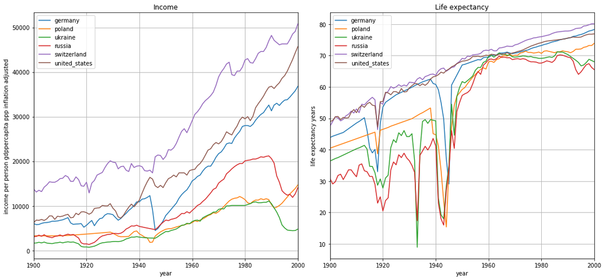

```python
_plot_overview(final_df)
```

### Looking at the plots some conclusions can be drawn directly:

- The first (1914-1918) and second (1939-1945) World War had a severe impact on the *life expectancy*.
- But remarkably, even worse then World War II on *life expectency* was the so called Holodomor in 1932-1933 in the Soviet Union, here represented by Ukraine and Russia.
- The relative increas of *life expectancy* was quite similar for all countries.
- The end of the soviet union decreased the *income* of the former soviet states to the level of the 1960s.

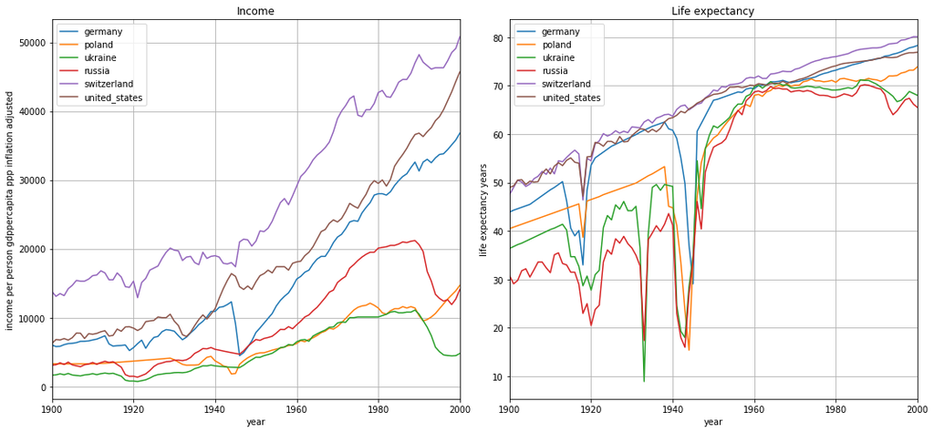

```python
_plot_overview(final_df)
```

### Further Investigations

- Is there a correlation between *income* and *life expectancy*?
- Which Country had the biggest relative increase in *income*?

### Is there a correlation between income and life expectancy?

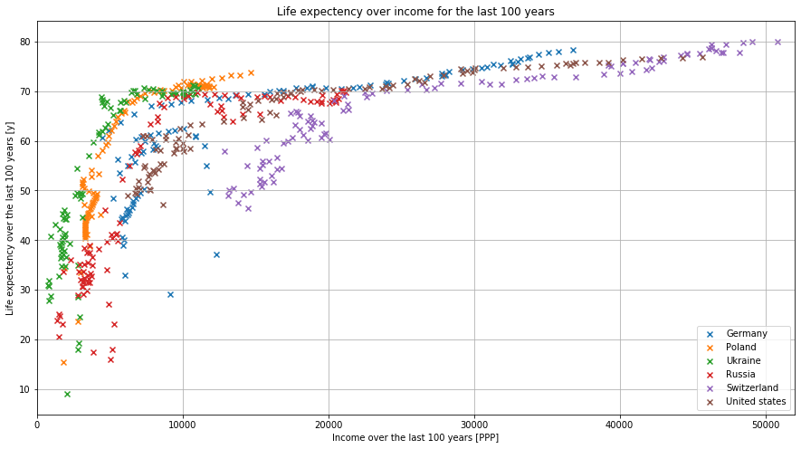

```python
_create_life_expectency_plots(final_df)
```

### Which Country had the biggest relative increase in income between 1900 and 2000?

To answer that question two bar chars with relative and absolute incomes are created. The bar colors represent the incomes in:

- 1900 the beginning of the last century
- 1969 the year of the Appollo 11 mission
- 1989 the end of the Soviet Union
- 2000 the end of the last millenium.

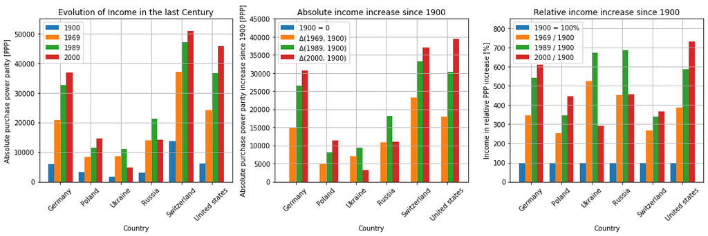

```python
_create_income_plots(final_df)
```

## Conclusions

### Is there a correlation between *income* and *life expectancy*?

- Lower income was generated in the World War periods, therefore the life expectancy was also low.
- Higher income was also generated in the second half of the last century, which came with a massive development in medicine and science.

### Which Country had the biggest increase in *income* over the last century?

- The highest *income* from the evaluated 6 countries hast Switzerland
- But considering the question which country had the highest increase in the last centruy, under both metrics, the absolute income increase and realative income increase it is the United States.